# Simulating the effect of sampling error in a model of variable plurals

## Data

This document uses frequency data from the SUBTLEX corpus, and probability data from a Timbl classifier.

Let’s load the data and take a look at it.

```r
set.seed(123)
load("pluralData.RData")
library(knitr)
kable(var[1:5,1:7], caption = "Part of the `var` dataset")
```

Part of the `var` dataset

| word | p_s | p_en | p_other | f_s | f_en | f_other |
| --- | --- | --- | --- | --- | --- | --- |
| aangifte | 0.231199 | 0.7688010 | 0 | 3 | 3 | 0 |
| aardappel | 0.857143 | 0.1428570 | 0 | 189 | 277 | 0 |
| adder | 0.958302 | 0.0416982 | 0 | 10 | 1 | 0 |
| adelaar | 0.785714 | 0.2142860 | 0 | 34 | 4 | 0 |
| ader | 0.800000 | 0.2000000 | 0 | 78 | 188 | 0 |

The **p_s** and **p_en** columns contain the probabilities from a Timbl model that predicts whether a noun takes an *-s* or *-en* plural suffix based on its similarity to other nouns.

The **f_s** and **f_en** columns contain the frequencies with which these nouns occur with an *-s* or *-en* suffix in the SUBTLEX corpus. As you can see, these nouns belong to the minority of Dutch plurals that occur with both suffixes.

Now let’s take a look at the other dataset we’ll be using.

```r
kable(invar[1:5,], caption = "Part of the `invar` dataset")
```

Part of the `invar` dataset

| word | f_mv | s_prop |
| --- | --- | --- |
| aak | 2 | 0 |
| aal | 14 | 0 |
| aalbes | 1 | 0 |
| aalmoes | 25 | 0 |
| aalmoezenier | 2 | 1 |

The **f_mv** column contains the SUBTLEX frequency of the plural for the nouns in the **word** column. The **s_prop** column reflects the proportion of plurals that are realized with an -s suffix. As this column only contains 1s and 0s you might have guessed that these plurals only occur with a single suffix.

## Description of the effect

Let’s say we’re interested in how well the probabilities from a Timbl model predict the actual proportion of *-s* and *-en* variants for the nouns in the `var` data set. We could create a regression model with **p_s** as a predictor. But are there any mediating variables we should take into account? We might expect the predictive quality of **p_s** to be dependent on the accuracy of the proportion of *-s* and *-en* variants. After all, if this proportion is based on only 3 tokens, it is probably less accurate than if it were based on 300 tokens. Not only should this result in more extreme residuals for inaccurate proportions, it should also result in a diminished relationship between **p_s** and *-s* proportion based on lower frequencies compared to a stronger relationship between **p_s** and *-s* proportion based on higher frequencies.

Let’s see if the data back this up.

```r
var = var[var$f_s != 0,]
var$f_nons = var$f_en + var$f_other
var$f_mv = var$f_s + var$f_nons
var$log_f_mv = log(var$f_mv)
var$s_prop = var$f_s/(var$f_s + var$f_nons)

library(aods3)
var.mod = aodml(cbind(f_s, f_nons) ~ p_s * log_f_mv, family = "bb", data = var)
kable(as.matrix(summary(var.mod)$BCoef), caption = "Coefficients")
```

Coefficients

|  | Estimate | Std. Error | z value | Pr(> \|z\|) |
| --- | --- | --- | --- | --- |
| (Intercept) | 0.5051933 | 0.1914501 | 2.638772 | 0.0083207 |
| p_s | -0.7184568 | 0.3248284 | -2.211804 | 0.0269802 |
| log_f_mv | -0.3930787 | 0.0474306 | -8.287453 | 0.0000000 |
| p_s:log_f_mv | 0.6047033 | 0.0809769 | 7.467606 | 0.0000000 |

The **p_s:log_f_mv** interaction is significant. Let’s visualize to help us interpret it. Unfortunately, the effects in `aodml` models cannot be plotted using packages such as `effects` of `ggeffects`. We’ll have construct these plots using the `predict` method. Let’s write a function that does this.

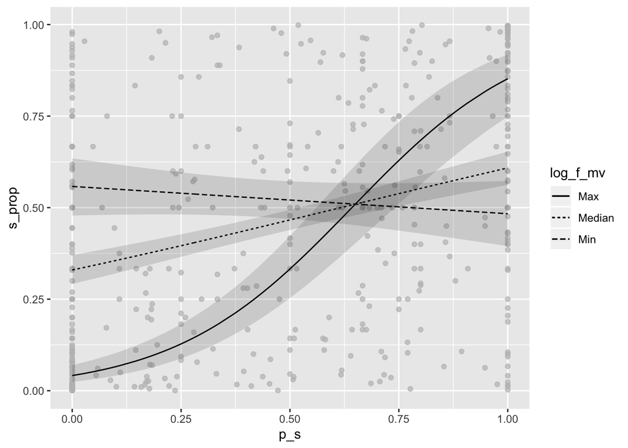

```r
plot_aodml_effect = function(var_data, var_mod){
  var2 = var_data
  var2$log_f_mv = max(var_data$log_f_mv)
  betabin_pred = predict(var_mod, se.fit = T, newdata = var2)
  s_prop_pred_max = plogis(betabin_pred$fit)
  s_prop_lo_max = plogis(betabin_pred$fit - qnorm(.975) * betabin_pred$se.fit)
  s_prop_hi_max = plogis(betabin_pred$fit + qnorm(.975) * betabin_pred$se.fit)

  var2$log_f_mv = median(var_data$log_f_mv)

  betabin_pred = predict(var_mod, se.fit = T, newdata = var2)
  s_prop_pred_med = plogis(betabin_pred$fit)
  s_prop_lo_med = plogis(betabin_pred$fit - qnorm(.975) * betabin_pred$se.fit)
  s_prop_hi_med = plogis(betabin_pred$fit + qnorm(.975) * betabin_pred$se.fit)

  var2$log_f_mv = min(var_data$log_f_mv)

  betabin_pred = predict(var_mod, se.fit = T, newdata = var2)
  s_prop_pred_min = plogis(betabin_pred$fit)
  s_prop_lo_min = plogis(betabin_pred$fit - qnorm(.975) * betabin_pred$se.fit)
  s_prop_hi_min = plogis(betabin_pred$fit + qnorm(.975) * betabin_pred$se.fit)

  library(ggplot2)
  var_plot = cbind(var_data, s_prop_pred_max, s_prop_lo_max, s_prop_hi_max,
                   s_prop_pred_med, s_prop_lo_med, s_prop_hi_med,
                   s_prop_pred_min, s_prop_lo_min, s_prop_hi_min)
  ggplot(var_plot, aes(x = p_s, y = s_prop)) +
         geom_point(color = "grey", alpha = .7) +
         geom_line(aes(y=s_prop_pred_max, linetype = "Max")) +
         geom_ribbon( aes(ymin = s_prop_lo_max, ymax = s_prop_hi_max), alpha = .15) +
         geom_line(aes(y=s_prop_pred_med, linetype = "Median")) +
         geom_ribbon( aes(ymin = s_prop_lo_med, ymax = s_prop_hi_med), alpha = .15) +
         geom_line(aes(y=s_prop_pred_min, linetype = "Min")) +
         geom_ribbon( aes(ymin = s_prop_lo_min, ymax = s_prop_hi_min), alpha = .15) +
         labs(linetype='log_f_mv')
}

plot_aodml_effect(var, var.mod)
```

As this plot indicates the effect of **p_s** on **s_prop** decreases as **log_f_mv** gets smaller. However, if this effect is truly the result of higher sampling error for words with fewer tokens, we should be able to replicate it in a simulation.

## Simulation

In order to simulate a somewhat realistic noun frequency distribution, we’ll use as much data as possible by combining the `var` and `invar` datasets. Word frequencies generally follow *lnre* (large number of rare events) distributions, which have been implemented in the `zipfR` package.

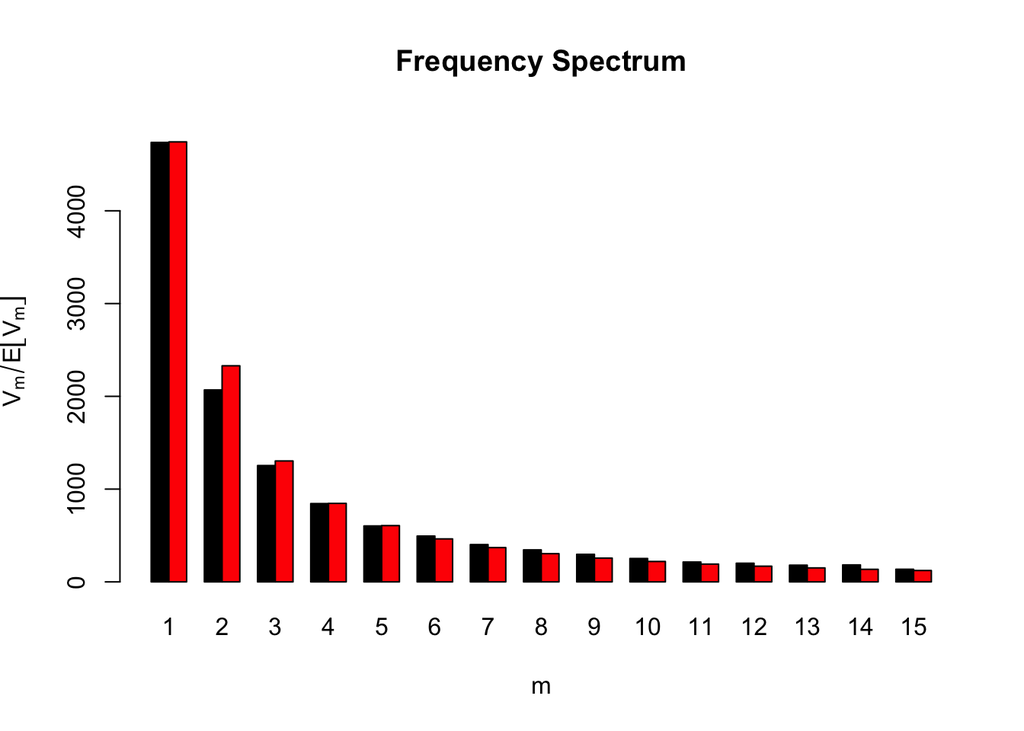

```r
nouns = rbind(invar, var[,c("word","f_mv", "s_prop")])
nouns.tab = table(nouns$f_mv)
library(zipfR)
nouns.spc = spc(m = as.numeric(names(nouns.tab)), Vm = as.numeric(nouns.tab))
nouns.lnre.fzm = lnre("fzm", nouns.spc)
plot(nouns.spc, lnre.spc(nouns.lnre.fzm, sum(nouns$f_mv)))
```

We’ll also simulate an appropriate beta distribution of `s_prop` using the `betareg` package.

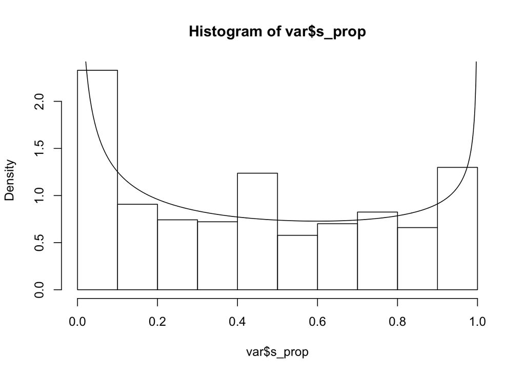

```r
library(betareg)
s_prop.beta = betareg(s_prop ~ 1, data = var)
mu = plogis(s_prop.beta$coefficients$mean)
phi = s_prop.beta$coefficients$precision
alph = mu * phi
bet = (1 - mu) * phi

hist(var$s_prop, freq = F)
p = seq(0, 1, length=nrow(var))
lines(p, dbeta(p, alph, bet), type = "l")
```

Now we can use these distributions to create the simulated population data from which we’ll sample.

```r
lnre.sample = rlnre(nouns.lnre.fzm,n=1000)
lnre.sample.num = as.numeric(as.character(lnre.sample))
beta.sample = rbeta(1000, alph, bet)

sim_data = data.frame(plural = 1:1000, frequency = lnre.sample.num, s_prop = beta.sample)
kable(head(sim_data), caption = "Simulated population data")
```

Simulated population data

| plural | frequency | s_prop |
| --- | --- | --- |
| 1 | 157 | 0.8169331 |
| 2 | 1145 | 0.0370193 |
| 3 | 260 | 0.0833490 |
| 4 | 2016 | 0.5100999 |
| 5 | 3502 | 0.9159213 |
| 6 | 20 | 0.3427563 |

Now let’s take a sample.

```r
sim_plur.list = mapply(function(x,y) sample(c("s", "nons"), x, TRUE, c(y, 1 - y)),
                       sim_data$frequency, sim_data$s_prop)
sim_plur_i.list = mapply(function(x,y) rep(x,y), sim_data$plural, sim_data$frequency)
sim_data_long = unlist(sim_plur.list)
names(sim_data_long) = as.character(unlist(sim_plur_i.list))

sim_data_sample = sample(sim_data_long, 10000, replace = FALSE)
sim_data_sample.df = data.frame(plural = names(sim_data_sample), suffix = sim_data_sample)
sim_data_sample.tab.wide = table(sim_data_sample.df$plural, sim_data_sample.df$suffix)
sim_data_sample.df.wide = data.frame(plural = as.integer(row.names(sim_data_sample.tab.wide)),
                                     nons = sim_data_sample.tab.wide[,1],
                                     s = sim_data_sample.tab.wide[,2])
sim_data_sample_var.df.wide = sim_data_sample.df.wide[!(sim_data_sample.df.wide$nons == 0 |
                                                          sim_data_sample.df.wide$s == 0),]
sim_data_sample_var.df.wide$true_s_prop = sapply(sim_data_sample_var.df.wide$plural,
                                                 function(x) sim_data[sim_data$plural == x,]$s_prop)
sim_data_sample_var.df.wide$mv_freq = sim_data_sample_var.df.wide$s + sim_data_sample_var.df.wide$nons
sim_data_sample_var.df.wide$log_f_mv = log(sim_data_sample_var.df.wide$mv_freq)
sim_data_sample_var.df.wide$s_prop = sim_data_sample_var.df.wide$s / sim_data_sample_var.df.wide$mv_freq
kable(head(sim_data_sample_var.df.wide), caption = "Simulated sample data")
```

Simulated sample data

|  | plural | nons | s | true_s_prop | mv_freq | log_f_mv | s_prop |
| --- | --- | --- | --- | --- | --- | --- | --- |
| 102 | 102 | 1 | 1 | 0.1481338 | 2 | 0.6931472 | 0.5000000 |
| 103 | 103 | 6 | 1 | 0.2487209 | 7 | 1.9459101 | 0.1428571 |
| 104 | 104 | 21 | 22 | 0.5250012 | 43 | 3.7612001 | 0.5116279 |
| 106 | 106 | 20 | 2 | 0.1137871 | 22 | 3.0910425 | 0.0909091 |
| 107 | 107 | 4 | 23 | 0.7642624 | 27 | 3.2958369 | 0.8518519 |
| 108 | 108 | 5 | 1 | 0.2701521 | 6 | 1.7917595 | 0.1666667 |

Let’s check the effect of sampling on the distribution of *-s* proportion by plotting **true_s_prop** (population proportions) and **s_prop** (sample proportions) against the the number of plural tokens, **log_f_mv**.

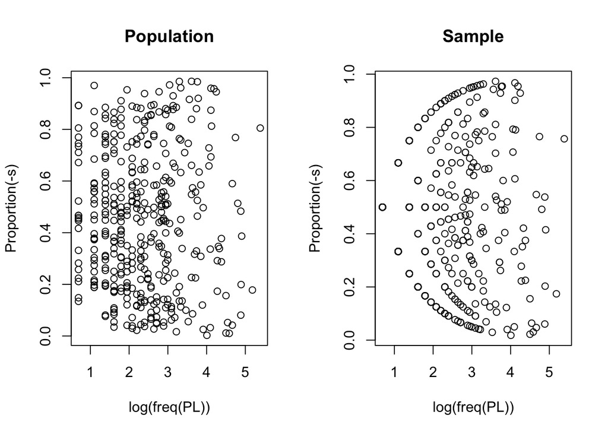

```r
par(mfrow=c(1,2))
plot(sim_data_sample_var.df.wide$log_f_mv, sim_data_sample_var.df.wide$true_s_prop, xlab = "log(freq(PL))", ylab = "Proportion(-s)", main="Population")
plot(sim_data_sample_var.df.wide$log_f_mv, sim_data_sample_var.df.wide$s_prop, xlab = "log(freq(PL))", ylab = "Proportion(-s)", main="Sample")
```

```r
par(mfrow=c(1,1))
```

We’re now ready to model the simulated data, by using **true_s_prop** as an analogue of **p_s** in the real data.

```r
sim_data_sample_var.df.wide$p_s = sim_data_sample_var.df.wide$true_s_prop
sim_data.mod = aodml(cbind(s, nons) ~ p_s * log_f_mv, family = "bb", data = sim_data_sample_var.df.wide)
kable(as.matrix(summary(sim_data.mod)$BCoef), caption = "Coefficients")
```

Coefficients

|  | Estimate | Std. Error | z value | Pr(> \|z\|) |
| --- | --- | --- | --- | --- |
| (Intercept) | -1.2174151 | 0.2318096 | -5.251790 | 2e-07 |
| p_s | 2.2962398 | 0.4649882 | 4.938276 | 8e-07 |
| log_f_mv | -0.3475399 | 0.0694320 | -5.005469 | 6e-07 |
| p_s:log_f_mv | 0.7365891 | 0.1407770 | 5.232310 | 2e-07 |

Again we find a significant interaction. Let’s check the plot:

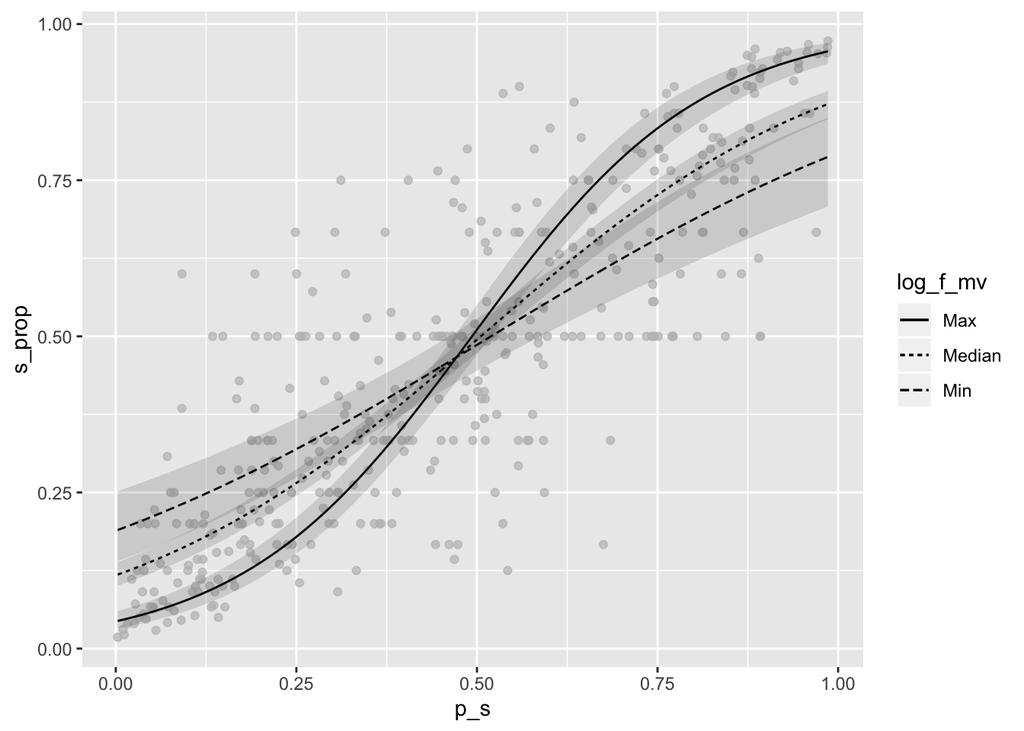

```r
plot_aodml_effect(sim_data_sample_var.df.wide, sim_data.mod)
```

Given this very similar effect in simulated data, it seems likely that the interaction between **p_s** and **log_f_mv** reflects differences in sampling error rather than some kind of linguistic effect.